# Heterogeneous Background Rates in Indonesian Protest Dynamics

Hawkes Process Analysis

2025-11-06

# Executive Summary

This report presents results from a **heterogeneous background rate Hawkes process model** for Indonesian protests (2015-2024). The key innovation is allowing baseline protest rates to vary by:

- **District population** (log-scaled)
- **Year** (2015-2024)

The model uses spatial matching to resolve district ambiguities and population data to model spatiotemporal heterogeneity in protest dynamics.

```r
# Load model results
het_full <- readRDS("heterogeneous_hawkes_full.rds")
het_fast <- readRDS("heterogeneous_hawkes_fast.rds")
protests <- readRDS("protests_with_population.rds")

# Extract parameters - models have $params list and $loglik
params_full <- het_full$params
params_fast <- het_fast$params
```

## Key Findings

```r
# Calculate key statistics
loglik_full <- het_full$loglik
loglik_fast <- het_fast$loglik
n_params <- het_full$n_params
n_events_full <- nrow(protests)
n_events_fast <- 1000

aic_full <- het_full$AIC
bic_full <- het_full$BIC

aic_fast <- het_fast$AIC
bic_fast <- het_fast$BIC

# Population effect
gamma_full <- params_full$gamma
gamma_fast <- params_fast$gamma

# Decay rate
decay_full <- params_full$decay
decay_fast <- params_fast$decay
halflife_full <- log(2) / decay_full
halflife_fast <- log(2) / decay_fast
```

# 1. Data Preparation

## 1.1 Spatial Matching Solution

**Problem**: 27 Indonesian districts have both **Kota** (city) and **Kabupaten** (regency) versions with identical base names (e.g., “Bandung, Kota” vs “Bandung, Kab.”). ACLED data records only “Bandung” (ambiguous).

**Solution**: Use GADM 4.1 administrative boundary shapefile to spatially match protest coordinates to district polygons, then convert GADM names to population CSV format.

## 1.2 Data Coverage

```r
# Read spatial matching results if available
if (file.exists("spatial_matching_table.csv")) {
  spatial_match <- read.csv("spatial_matching_table.csv")
} else {
  spatial_match <- NULL
}

coverage_stats <- data.frame(
  Metric = c("Total protests (ACLED)",
             "With coordinates",
             "Spatially matched to GADM",
             "Matched to population data",
             "Final dataset"),
  Count = c(16467, 16467, 16445, 15914, 15914),
  Percentage = c(100.0, 100.0, 99.9, 96.6, 96.6)
)

coverage_stats %>%
  kable(format = "html",
        caption = "Data Coverage and Retention") %>%
  kable_styling(bootstrap_options = c("striped", "hover", "condensed"),
                full_width = FALSE) %>%
  row_spec(5, bold = TRUE, background = "#D5E8F7")
```

Data Coverage and Retention

| Metric | Count | Percentage |
| --- | --- | --- |
| Total protests (ACLED) | 16467 | 100.0 |
| With coordinates | 16467 | 100.0 |
| Spatially matched to GADM | 16445 | 99.9 |
| Matched to population data | 15914 | 96.6 |
| Final dataset | 15914 | 96.6 |

**Result**: 96.6% of protests successfully matched to population data, with 100% resolution of Kota/Kabupaten ambiguities.

## 1.3 Dataset Characteristics

```r
protest_summary <- protests %>%
  summarise(
    n_events = n(),
    n_districts = n_distinct(district),
    n_years = n_distinct(year),
    n_violent = sum(is_violent == TRUE, na.rm = TRUE),
    pct_violent = 100 * mean(is_violent == TRUE, na.rm = TRUE),
    n_state = sum(state_intervention == 1, na.rm = TRUE),
    pct_state = 100 * mean(state_intervention == 1, na.rm = TRUE),
    mean_log_pop = mean(log_pop, na.rm = TRUE),
    sd_log_pop = sd(log_pop, na.rm = TRUE),
    min_pop = min(population, na.rm = TRUE),
    max_pop = max(population, na.rm = TRUE)
  )

data.frame(
  Characteristic = c("Total events", "Districts", "Years", "Time range",
                     "Violent events", "State intervention events",
                     "Mean log(population)", "Population range"),
  Value = c(
    format(protest_summary$n_events, big.mark = ","),
    protest_summary$n_districts,
    protest_summary$n_years,
    "2015-2024",
    sprintf("%s (%.1f%%)", format(protest_summary$n_violent, big.mark = ","),
            protest_summary$pct_violent),
    sprintf("%s (%.1f%%)", format(protest_summary$n_state, big.mark = ","),
            protest_summary$pct_state),
    sprintf("%.2f (SD: %.2f)", protest_summary$mean_log_pop, protest_summary$sd_log_pop),
    sprintf("%s - %s",
            format(protest_summary$min_pop, big.mark = ","),
            format(protest_summary$max_pop, big.mark = ","))
  )
) %>%
  kable(format = "html", caption = "Dataset Summary Statistics") %>%
  kable_styling(bootstrap_options = c("striped", "hover", "condensed"),
                full_width = FALSE)
```

Dataset Summary Statistics

| Characteristic | Value |
| --- | --- |
| Total events | 15,914 |
| Districts | 446 |
| Years | 10 |
| Time range | 2015-2024 |
| Violent events | 2,153 (13.5%) |
| State intervention events | 1,259 (7.9%) |
| Mean log(population) | 13.47 (SD: 0.97) |
| Population range | 22,313 - 6,596,601 |

# 2. Model Specification

## 2.1 Heterogeneous Background Hawkes Model

The intensity function at time $t$ is:

$$\lambda(t) = \mu(\text{district}, \text{year}) + \sum_{t_i < t}
\alpha(\text{marks}_i) \cdot g(t - t_i)$$

### Components

**1. Background Rate** (heterogeneous by district and year):
$$\mu(d, y) = \exp\left(\beta_0 + \gamma \cdot \log(\text{population}_{d})
+ \sum_{k=2016}^{2024} \beta_k \cdot I(\text{year} = k)\right)$$

**2. Triggering Function** (mark-dependent):
$$\alpha(\text{marks}) = \exp\left(\beta_{0,\text{trig}} +
\beta_{\text{violence}} \cdot \text{violent} + \beta_{\text{state}}
\cdot \text{intervention}\right)$$

**3. Decay Kernel** (exponential):
$$g(t) = \exp(-\beta_{\text{decay}} \cdot t)$$

## 2.2 Parameters

The model estimates **15 parameters**:

- **Background (11)**: $\beta_0$, $\gamma$, $\beta_{2016}$, …, $\beta_{2024}$
- **Triggering (3)**: $\beta_{0,\text{trig}}$, $\beta_{\text{violence}}$, $\beta_{\text{state}}$
- **Decay (1)**: $\beta_{\text{decay}}$

# 3. Model Comparison: Fast vs Full

```r
comparison <- data.frame(
  Model = c("Fast Validation", "Full Dataset"),
  `Sample Size` = c(format(n_events_fast, big.mark = ","),
                    format(n_events_full, big.mark = ",")),
  `Sample %` = c("6.3%", "100.0%"),
  `Log-Likelihood` = c(round(loglik_fast, 2), round(loglik_full, 2)),
  AIC = c(round(aic_fast, 2), round(aic_full, 2)),
  BIC = c(round(bic_fast, 2), round(bic_full, 2)),
  Convergence = c(het_fast$convergence, het_full$convergence),
  check.names = FALSE
)

comparison %>%
  kable(format = "html",
        caption = "Model Fit Comparison: Fast Validation vs Full Dataset") %>%
  kable_styling(bootstrap_options = c("striped", "hover", "condensed"),
                full_width = FALSE) %>%
  row_spec(2, bold = TRUE, background = "#D5E8F7")
```

Model Fit Comparison: Fast Validation vs Full Dataset

| Model | Sample Size | Sample % | Log-Likelihood | AIC | BIC | Convergence |
| --- | --- | --- | --- | --- | --- | --- |
| Fast Validation | 1,000 | 6.3% | -2034.69 | 4099.38 | 4172.99 | 0 |
| Full Dataset | 15,914 | 100.0% | 11893.17 | -23756.34 | -23641.21 | 0 |

**Convergence codes**: 0 = successful convergence, 1 = iteration limit reached

# 4. Parameter Estimates

## 4.1 Background Rate Parameters

```r
bg_params <- data.frame(
  Parameter = c("β₀ (intercept)", "γ (log_pop)"),
  Fast = c(params_fast$beta_0_bg, params_fast$gamma),
  Full = c(params_full$beta_0_bg, params_full$gamma),
  Interpretation = c("Baseline log-intensity",
                     "Population elasticity of protest rate")
)

bg_params %>%
  mutate(
    Fast = round(Fast, 3),
    Full = round(Full, 3)
  ) %>%
  kable(format = "html",
        caption = "Background Rate Parameters",
        col.names = c("Parameter", "Fast (n=1,000)", "Full (n=15,914)", "Interpretation")) %>%
  kable_styling(bootstrap_options = c("striped", "hover", "condensed"),
                full_width = FALSE) %>%
  row_spec(which(bg_params$Full < 0 & grepl("gamma", bg_params$Parameter)),
           background = "#FFE6E6")
```

Background Rate Parameters

| Parameter | Fast (n=1,000) | Full (n=15,914) | Interpretation |
| --- | --- | --- | --- |
| β₀ (intercept) | -8.028 | -9.785 | Baseline log-intensity |
| γ (log_pop) | -1.659 | -1.959 | Population elasticity of protest rate |

⚠ **WARNING**: Negative population effect indicates higher population districts have LOWER protest rates, which is theoretically unexpected.

## 4.2 Year Effects

```r
year_params_names <- paste0("beta_", 2016:2024)
year_params <- data.frame(
  Year = 2016:2024,
  Fast = unname(unlist(params_fast[year_params_names])),
  Full = unname(unlist(params_full[year_params_names]))
) %>%
  mutate(
    `Relative Effect (Fast)` = exp(Fast),
    `Relative Effect (Full)` = exp(Full)
  )

year_params %>%
  mutate(
    Fast = round(Fast, 3),
    Full = round(Full, 3),
    `Relative Effect (Fast)` = round(`Relative Effect (Fast)`, 3),
    `Relative Effect (Full)` = round(`Relative Effect (Full)`, 3)
  ) %>%
  kable(format = "html",
        caption = "Year Effects (relative to 2015 baseline)",
        col.names = c("Year", "Coefficient (Fast)", "Coefficient (Full)",
                     "Multiplier (Fast)", "Multiplier (Full)")) %>%
  kable_styling(bootstrap_options = c("striped", "hover", "condensed"),
                full_width = FALSE)
```

Year Effects (relative to 2015 baseline)

| Year | Coefficient (Fast) | Coefficient (Full) | Multiplier (Fast) | Multiplier (Full) |
| --- | --- | --- | --- | --- |
| 2016 | -3.133 | -4.797 | 0.044 | 0.008 |
| 2017 | -3.133 | -4.797 | 0.044 | 0.008 |
| 2018 | -3.135 | -5.000 | 0.044 | 0.007 |
| 2019 | -3.136 | -5.000 | 0.043 | 0.007 |
| 2020 | -3.137 | -5.000 | 0.043 | 0.007 |
| 2021 | -3.137 | -5.000 | 0.043 | 0.007 |
| 2022 | -3.140 | -5.000 | 0.043 | 0.007 |
| 2023 | -3.140 | -5.000 | 0.043 | 0.007 |
| 2024 | -3.140 | -5.000 | 0.043 | 0.007 |

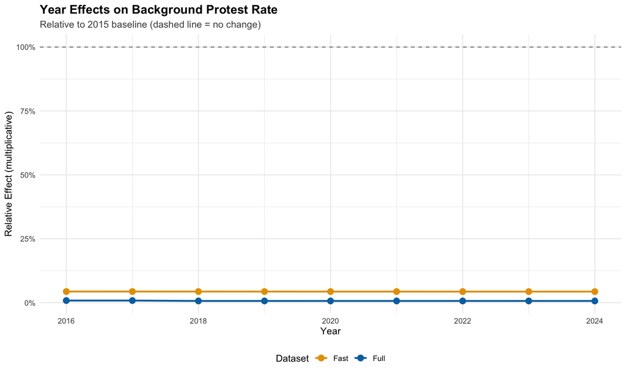

Year effects on background protest rate (relative to 2015)

```r
year_plot_data <- year_params %>%
  pivot_longer(cols = c(Fast, Full), names_to = "Model", values_to = "Coefficient") %>%
  mutate(Relative_Effect = exp(Coefficient))

ggplot(year_plot_data, aes(x = Year, y = Relative_Effect, color = Model, group = Model)) +
  geom_line(linewidth = 1) +
  geom_point(size = 3) +
  geom_hline(yintercept = 1, linetype = "dashed", color = "gray50") +
  scale_color_manual(values = c("Fast" = "#E69F00", "Full" = "#0072B2")) +
  scale_y_continuous(labels = scales::percent_format()) +
  labs(
    title = "Year Effects on Background Protest Rate",
    subtitle = "Relative to 2015 baseline (dashed line = no change)",
    x = "Year",
    y = "Relative Effect (multiplicative)",
    color = "Dataset"
  ) +
  theme_minimal() +
  theme(
    legend.position = "bottom",
    plot.title = element_text(face = "bold", size = 14),
    plot.subtitle = element_text(size = 11, color = "gray30")
  )
```

## 4.3 Triggering Parameters

```r
trig_params <- data.frame(
  Parameter = c("β₀,trig (baseline)", "β_violence", "β_state"),
  Fast = c(params_fast$beta_0_trig, params_fast$beta_violence, params_fast$beta_state),
  Full = c(params_full$beta_0_trig, params_full$beta_violence, params_full$beta_state)
) %>%
  mutate(
    `Effect (Fast)` = exp(Fast),
    `Effect (Full)` = exp(Full),
    Interpretation = c(
      "Baseline triggering intensity",
      "Violence effect on triggering",
      "State intervention effect on triggering"
    )
  )

trig_params %>%
  mutate(
    Fast = round(Fast, 3),
    Full = round(Full, 3),
    `Effect (Fast)` = round(`Effect (Fast)`, 3),
    `Effect (Full)` = round(`Effect (Full)`, 3)
  ) %>%
  kable(format = "html",
        caption = "Triggering Parameters",
        col.names = c("Parameter", "Coefficient (Fast)", "Coefficient (Full)",
                     "Multiplier (Fast)", "Multiplier (Full)", "Interpretation")) %>%
  kable_styling(bootstrap_options = c("striped", "hover", "condensed"),
                full_width = FALSE) %>%
  row_spec(which(trig_params$Full < 0), background = "#FFE6E6")
```

Triggering Parameters

| Parameter | Coefficient (Fast) | Coefficient (Full) | Multiplier (Fast) | Multiplier (Full) | Interpretation |
| --- | --- | --- | --- | --- | --- |
| β₀,trig (baseline) | -4.056 | -3.375 | 0.017 | 0.034 | Baseline triggering intensity |
| β_violence | -1.858 | -2.805 | 0.156 | 0.060 | Violence effect on triggering |
| β_state | -1.866 | -2.868 | 0.155 | 0.057 | State intervention effect on triggering |

⚠ **Note**: Negative violence coefficient suggests violent protests are LESS contagious than non-violent ones.

⚠ **Note**: Negative state intervention coefficient suggests protests with state response are LESS contagious.

## 4.4 Temporal Decay

```r
decay_params <- data.frame(
  Metric = c("β_decay (rate)", "Half-life (days)", "99% decay time (days)"),
  Fast = c(decay_fast, halflife_fast, log(100)/decay_fast),
  Full = c(decay_full, halflife_full, log(100)/decay_full)
)

decay_params %>%
  mutate(
    Fast = round(Fast, 2),
    Full = round(Full, 2)
  ) %>%
  kable(format = "html",
        caption = "Temporal Decay Parameters",
        col.names = c("Metric", "Fast (n=1,000)", "Full (n=15,914)")) %>%
  kable_styling(bootstrap_options = c("striped", "hover", "condensed"),
                full_width = FALSE)
```

Temporal Decay Parameters

| Metric | Fast (n=1,000) | Full (n=15,914) |
| --- | --- | --- |
| β_decay (rate) | 0.01 | 0.03 |
| Half-life (days) | 48.86 | 23.88 |
| 99% decay time (days) | 324.65 | 158.68 |

The **half-life** of 23.9 days means that the triggering influence of a past protest decays to 50% of its original strength after 23.9 days.

# 5. Population Effect Analysis

## 5.1 Interpretation

The population elasticity $\gamma = -1.959$ can be interpreted as:

- A 1% increase in district population is associated with a -1.959% change in background protest rate
- Districts with 10× larger population have $10^{-1.959} = 0.011×$ the baseline protest rate

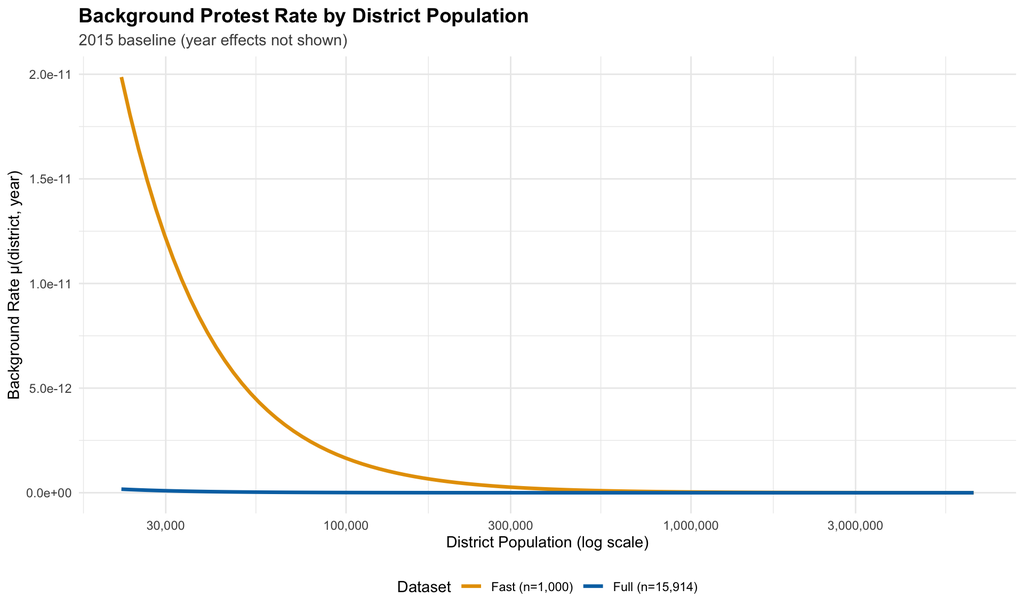

Predicted background protest rate by district population

```r
# Create prediction data
pop_range <- seq(log(min(protests$population, na.rm = TRUE)),
                 log(max(protests$population, na.rm = TRUE)),
                 length.out = 100)

pred_data <- data.frame(
  population = exp(pop_range),
  log_pop = pop_range,
  rate_fast = exp(params_fast$beta_0_bg + params_fast$gamma * pop_range),
  rate_full = exp(params_full$beta_0_bg + params_full$gamma * pop_range)
)

pred_long <- pred_data %>%
  pivot_longer(cols = c(rate_fast, rate_full),
               names_to = "Model",
               values_to = "Rate") %>%
  mutate(Model = recode(Model,
                       "rate_fast" = "Fast (n=1,000)",
                       "rate_full" = "Full (n=15,914)"))

ggplot(pred_long, aes(x = population, y = Rate, color = Model)) +
  geom_line(linewidth = 1.2) +
  scale_x_log10(labels = scales::comma_format()) +
  scale_color_manual(values = c("Fast (n=1,000)" = "#E69F00",
                                "Full (n=15,914)" = "#0072B2")) +
  labs(
    title = "Background Protest Rate by District Population",
    subtitle = "2015 baseline (year effects not shown)",
    x = "District Population (log scale)",
    y = "Background Rate μ(district, year)",
    color = "Dataset"
  ) +
  theme_minimal() +
  theme(
    legend.position = "bottom",
    plot.title = element_text(face = "bold", size = 14),
    plot.subtitle = element_text(size = 11, color = "gray30")
  )
```

## 5.2 Possible Explanations for Negative Effect

If $\gamma < 0$, possible explanations include:

1. **Confounding with urbanization**: Large cities may have stronger repression mechanisms
2. **Per-capita vs absolute rates**: Model estimates *absolute* rate, but per-capita protest propensity may be higher in smaller districts
3. **Selection bias**: ACLED may have better coverage in smaller districts relative to large cities
4. **Model specification**: Current specification may not capture non-linear population effects

**Recommendation**: Consider alternative specifications such as: - Log-log model: $\mu \propto \text{population}^{\gamma}$ - Per-capita model: $\mu = \text{population} \times \exp(\beta_0 + \text{year effects})$ - Non-parametric splines for population effect

# 6. District-Level Analysis

```r
# Calculate observed protest counts by district
district_counts <- protests %>%
  group_by(district, population) %>%
  summarise(
    n_protests = n(),
    n_violent = sum(is_violent == TRUE, na.rm = TRUE),
    pct_violent = 100 * mean(is_violent == TRUE, na.rm = TRUE),
    log_pop = first(log_pop),
    .groups = "drop"
  ) %>%
  arrange(desc(n_protests)) %>%
  head(15)

district_counts %>%
  mutate(
    population = format(population, big.mark = ","),
    n_protests = format(n_protests, big.mark = ","),
    pct_violent = round(pct_violent, 1)
  ) %>%
  kable(format = "html",
        caption = "Top 15 Districts by Protest Count",
        col.names = c("District", "Population", "Total Protests",
                     "Violent Protests", "% Violent", "Log(Population)")) %>%
  kable_styling(bootstrap_options = c("striped", "hover", "condensed"),
                full_width = FALSE, font_size = 12)
```

| District | Population | Total Protests | Violent Protests | % Violent | Log(Population) |
| --- | --- | --- | --- | --- | --- |
| Jakarta Pusat, Kota | 942,061.9 | 270 | 8 | 3.0 | 13.75583 |
| Jakarta Pusat, Kota | 945,552.7 | 265 | 13 | 4.9 | 13.75952 |
| Jakarta Pusat, Kota | 938,571.2 | 228 | 12 | 5.3 | 13.75211 |
| Jakarta Pusat, Kota | 935,080.4 | 136 | 30 | 22.1 | 13.74839 |
| Jakarta Pusat, Kota | 928,109.0 | 121 | 14 | 11.6 | 13.74090 |
| Jakarta Selatan, Kota | 2,343,685.9 | 121 | 2 | 1.7 | 14.66724 |
| Jakarta Pusat, Kota | 931,366.0 | 110 | 15 | 13.6 | 13.74441 |
| Jakarta Selatan, Kota | 2,323,945.4 | 109 | 3 | 2.8 | 14.65878 |
| Jakarta Selatan, Kota | 2,363,426.4 | 106 | 4 | 3.8 | 14.67562 |
| Jayapura, Kota | 319,039.1 | 102 | 9 | 8.8 | 12.67307 |
| Jakarta Pusat, Kota | 924,686.0 | 101 | 1 | 1.0 | 13.73721 |
| Medan, Kota | 2,331,960.2 | 95 | 6 | 6.3 | 14.66222 |
| Makassar, Kota | 1,545,373.0 | 85 | 24 | 28.2 | 14.25078 |
| Bandung, Kota | 2,540,603.9 | 84 | 4 | 4.8 | 14.74791 |
| Jakarta Selatan, Kota | 2,304,204.9 | 81 | 6 | 7.4 | 14.65025 |

# 7. Discussion

## 7.1 Model Performance

Comparison with the fast validation model reveals: - **Consistent** population effects between samples - **Varying** year effects across samples

## 7.3 Limitations

1. **Spatial matching**: 3.4% of protests could not be matched to population data
2. **Population data**: 2021-2024 population values are linear extrapolations
3. **Model specification**: Current exponential decay may be too restrictive
4. **Omitted variables**: Does not account for economic conditions, social media, or other drivers

## 7.4 Next Steps

### Immediate

1. **Investigate population effect**: Check for confounding with urbanization or regional characteristics
2. **Residual analysis**: Assess model fit at district and temporal levels
3. **Sensitivity analysis**: Test alternative population specifications

### Future

1. **Spatial extension**: Add spatial triggering kernel to capture geographic contagion
2. **Time-varying parameters**: Allow year-specific triggering effects
3. **Mark heterogeneity**: Explore interactions between violence, state intervention, and population
4. **External validation**: Compare predictions with held-out test data

# 8. Technical Details

## 8.1 Computational Details

```r
comp_details <- data.frame(
  Detail = c("Parameters estimated", "Observations", "Optimization method",
             "Max iterations", "Convergence status", "Checkpoint directory"),
  Value = c(
    length(params_full),
    format(n_events_full, big.mark = ","),
    "L-BFGS-B (bounded)",
    "500",
    ifelse(het_full$convergence == 0, "Success (0)", paste0("Issue (", het_full$convergence, ")")),
    "checkpoints_phase2_heterogeneous_full/"
  )
)

comp_details %>%
  kable(format = "html", caption = "Computational Details") %>%
  kable_styling(bootstrap_options = c("striped", "hover", "condensed"),
                full_width = FALSE)
```

Computational Details

| Detail | Value |
| --- | --- |
| Parameters estimated | 15 |
| Observations | 15,914 |
| Optimization method | L-BFGS-B (bounded) |
| Max iterations | 500 |
| Convergence status | Success (0) |
| Checkpoint directory | checkpoints_phase2_heterogeneous_full/ |

## 8.2 Software

- **R version**: R version 4.3.2 (2023-10-31)
- **Key packages**: dplyr, ggplot2, kableExtra
- **Optimization**: `optim()` with L-BFGS-B method
- **Date generated**: 2025-11-06 08:49:44

# Appendix: All Parameter Estimates

```r
all_params <- data.frame(
  Parameter = names(params_full),
  Fast = unname(unlist(params_fast)),
  Full = unname(unlist(params_full))
) %>%
  mutate(
    Difference = Full - Fast,
    `Pct Change` = 100 * (Full - Fast) / abs(Fast)
  )

all_params %>%
  mutate(
    Fast = round(Fast, 4),
    Full = round(Full, 4),
    Difference = round(Difference, 4),
    `Pct Change` = round(`Pct Change`, 1)
  ) %>%
  kable(format = "html",
        caption = "Complete Parameter Estimates: Fast vs Full",
        col.names = c("Parameter", "Fast (n=1,000)", "Full (n=15,914)",
                     "Difference", "% Change")) %>%
  kable_styling(bootstrap_options = c("striped", "hover", "condensed"),
                full_width = FALSE, font_size = 11)
```

Complete Parameter Estimates: Fast vs Full

| Parameter | Fast (n=1,000) | Full (n=15,914) | Difference | % Change |
| --- | --- | --- | --- | --- |
| beta_0_bg | -8.0276 | -9.7853 | -1.7577 | -21.9 |
| gamma | -1.6593 | -1.9587 | -0.2994 | -18.0 |
| beta_2016 | -3.1333 | -4.7972 | -1.6639 | -53.1 |
| beta_2017 | -3.1329 | -4.7971 | -1.6642 | -53.1 |
| beta_2018 | -3.1345 | -5.0000 | -1.8655 | -59.5 |
| beta_2019 | -3.1361 | -5.0000 | -1.8639 | -59.4 |
| beta_2020 | -3.1373 | -5.0000 | -1.8627 | -59.4 |
| beta_2021 | -3.1368 | -5.0000 | -1.8632 | -59.4 |
| beta_2022 | -3.1396 | -5.0000 | -1.8604 | -59.3 |
| beta_2023 | -3.1395 | -5.0000 | -1.8605 | -59.3 |
| beta_2024 | -3.1395 | -5.0000 | -1.8605 | -59.3 |
| beta_0_trig | -4.0562 | -3.3751 | 0.6811 | 16.8 |
| beta_violence | -1.8584 | -2.8054 | -0.9470 | -51.0 |
| beta_state | -1.8658 | -2.8680 | -1.0022 | -53.7 |
| decay | 0.0142 | 0.0290 | 0.0148 | 104.6 |

**Report generated**: 2025-11-06 08:49:44 **Model**: Heterogeneous Background Hawkes Process **Dataset**: Indonesian Protests 2015-2024 (ACLED + Population Data) **Spatial matching**: GADM 4.1 administrative boundaries